# Homework 3

Ginevra Carbone

## Exercise 1

**TH-1:** Probit model - Start from the logistic model on slide 20 `1992polls.stan` and write the probit specification of the model using the `target+=` sintax in the model block and the `bernoulli_lpmf` function (for any doubt, see the Stan manual documentation in the Stan website). Simulate 1000 draws using the `1992polls` data and compare the results with the ones obtained using the `rstanarm::stan_glm` function.

### Probit model

```r
# loading clean data
source("4.7_Fitting a series of regressions.R",
       echo=FALSE)
yr <- 1992
ok <- nes.year==yr & presvote<3
vote <- presvote[ok] - 1
income <- data$income[ok]

# fitting glm model
fit.glm <- rstanarm::stan_glm (vote ~ income, family=binomial(link="probit"))
# fitting stan model
data_1992 <- list(N = 1179,
                  vote = vote[is.na(vote)==FALSE],
                  income = income[is.na(income)==FALSE])
fit.rstan <- stan('probit_1992polls.stan',
              data = data_1992,
              pars = c("alpha", "beta"),
              iter = 1000,
              chains =4)
# printing results
print(fit.glm)
```

```
## stan_glm
##  family:       binomial [probit]
##  formula:      vote ~ income
##  observations: 1179
##  predictors:   2
## ------
##             Median MAD_SD
## (Intercept) -0.9    0.1
## income       0.2    0.0
##
## Sample avg. posterior predictive distribution of y:
##          Median MAD_SD
## mean_PPD 0.4    0.0
##
## ------
## * For help interpreting the printed output see ?print.stanreg
## * For info on the priors used see ?prior_summary.stanreg
```

```r
print(fit.rstan)
```

```
## Inference for Stan model: probit_1992polls.
## 4 chains, each with iter=1000; warmup=500; thin=1;
## post-warmup draws per chain=500, total post-warmup draws=2000.
##
##          mean se_mean   sd    2.5%     25%     50%     75%   97.5% n_eff
## alpha   -0.87    0.00 0.11   -1.08   -0.94   -0.87   -0.79   -0.67   659
## beta     0.20    0.00 0.03    0.14    0.18    0.20    0.22    0.27   629
## lp__  -784.46    0.04 0.96 -787.01 -784.79 -784.17 -783.78 -783.51   674
##       Rhat
## alpha    1
## beta     1
## lp__     1
##
## Samples were drawn using NUTS(diag_e) at Wed May 29 11:44:08 2019.
## For each parameter, n_eff is a crude measure of effective sample size,
## and Rhat is the potential scale reduction factor on split chains (at
## convergence, Rhat=1).
```

[figure not shown]

### Comparison with different priors

```r
# cauchy priors
fit2.rstan <- stan('cauchy_prior-1992polls.stan',
              data = data_1992,
              pars = c("alpha", "beta"),
              iter = 1000,
              chains =4)
print(fit2.rstan)
```

```
## Inference for Stan model: cauchy_prior-1992polls.
## 4 chains, each with iter=1000; warmup=500; thin=1;
## post-warmup draws per chain=500, total post-warmup draws=2000.
##
##          mean se_mean   sd    2.5%     25%     50%     75%   97.5% n_eff
## alpha   -0.86    0.01 0.12   -1.08   -0.94   -0.87   -0.78   -0.63   454
## beta     0.20    0.00 0.04    0.13    0.18    0.20    0.22    0.27   453
## lp__  -785.00    0.05 1.09 -787.67 -785.40 -784.69 -784.25 -783.98   434
##       Rhat
## alpha 1.00
## beta  1.01
## lp__  1.01
##
## Samples were drawn using NUTS(diag_e) at Wed May 29 11:44:17 2019.
## For each parameter, n_eff is a crude measure of effective sample size,
## and Rhat is the potential scale reduction factor on split chains (at
## convergence, Rhat=1).
```

```r
# normal non informative priors
fit3.rstan <- stan('non_inf_prior-1992polls.stan',
              data = data_1992,
              pars = c("alpha", "beta"),
              iter = 1000,
              chains =4)
print(fit3.rstan)
```

```
## Inference for Stan model: non_inf_prior-1992polls.
## 4 chains, each with iter=1000; warmup=500; thin=1;
## post-warmup draws per chain=500, total post-warmup draws=2000.
##
##          mean se_mean   sd    2.5%     25%     50%     75%   97.5% n_eff
## alpha   -0.87    0.01 0.12   -1.10   -0.95   -0.87   -0.79   -0.63   343
## beta     0.20    0.00 0.04    0.13    0.18    0.20    0.23    0.27   376
## lp__  -790.51    0.05 1.01 -793.22 -790.93 -790.21 -789.78 -789.51   494
##       Rhat
## alpha 1.01
## beta  1.01
## lp__  1.01
##
## Samples were drawn using NUTS(diag_e) at Wed May 29 11:44:23 2019.
## For each parameter, n_eff is a crude measure of effective sample size,
## and Rhat is the potential scale reduction factor on split chains (at
## convergence, Rhat=1).
```

Using a non-informative normal prior or a weakly informative cauchy prior on the parameters does not influence `Rhat`, `alpha` and `beta` predictions. We can only notice small variations in the effective sample size.

## Exercise 2

**LAB-1:** Using the most appropriate graphical tools of the `bayesplot` package, analyze the models fitted during the 4th and 5th lab sessions on the cockroaches dataset and comment.

### Stan model load and fit

```r
# load hierarchical data
#stan_dat_hier <- #readRDS('../../labs/lab5/pest_data_longer_stan_dat.RDS')

# load and fit stan model
comp_model_NB_hier_ncp <- stan_model('../../labs/lab5/hier_NB_regression_ncp.stan')
```

```
## recompiling to avoid crashing R session
```

```r
fitted_model_NB_hier_ncp <- sampling(comp_model_NB_hier_ncp, data = stan_dat_hier, chains = 4, cores = 4)

# this is the non-centered model with no divergences
print(fitted_model_NB_hier_ncp, pars = c('sigma_mu','beta','alpha','phi','mu'))
```

```
## Inference for Stan model: hier_NB_regression_ncp.
## 4 chains, each with iter=2000; warmup=1000; thin=1;
## post-warmup draws per chain=1000, total post-warmup draws=4000.
##
##           mean se_mean   sd  2.5%   25%   50%   75% 97.5% n_eff Rhat
## sigma_mu  0.23    0.01 0.18  0.01  0.10  0.20  0.32  0.67  1207    1
## beta     -0.23    0.00 0.06 -0.35 -0.27 -0.23 -0.18 -0.11  2777    1
## alpha     1.24    0.01 0.44  0.39  0.94  1.24  1.53  2.15  2725    1
## phi       1.58    0.01 0.34  1.04  1.34  1.54  1.77  2.36  4482    1
## mu[1]     1.25    0.01 0.56  0.17  0.88  1.25  1.62  2.35  2690    1
## mu[2]     1.19    0.01 0.54  0.14  0.84  1.20  1.56  2.25  2887    1
## mu[3]     1.37    0.01 0.49  0.41  1.04  1.37  1.71  2.36  3251    1
## mu[4]     1.41    0.01 0.50  0.45  1.07  1.41  1.74  2.41  3031    1
## mu[5]     1.06    0.01 0.42  0.24  0.78  1.06  1.33  1.91  3255    1
## mu[6]     1.15    0.01 0.50  0.16  0.82  1.16  1.48  2.14  2830    1
## mu[7]     1.43    0.01 0.52  0.41  1.09  1.42  1.77  2.47  3178    1
## mu[8]     1.23    0.01 0.44  0.38  0.93  1.22  1.52  2.11  3644    1
## mu[9]     1.40    0.01 0.57  0.28  1.03  1.41  1.78  2.53  2783    1
## mu[10]    0.85    0.01 0.38  0.13  0.59  0.84  1.10  1.63  3689    1
##
## Samples were drawn using NUTS(diag_e) at Wed May 29 11:35:11 2019.
## For each parameter, n_eff is a crude measure of effective sample size,
## and Rhat is the potential scale reduction factor on split chains (at
## convergence, Rhat=1).
```

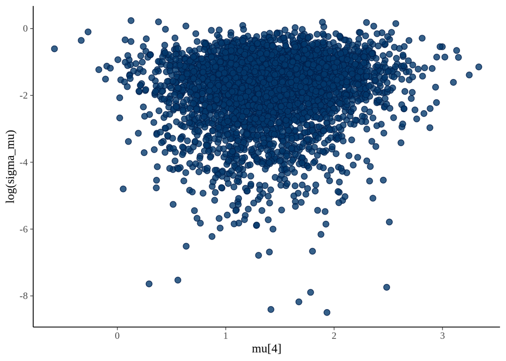

```r
scatter_no_divs <- mcmc_scatter(
  as.array(fitted_model_NB_hier_ncp),
  pars = c("mu[4]", 'sigma_mu'),
  transform = list('sigma_mu' = "log"),
  np = nuts_params(fitted_model_NB_hier_ncp)
)
scatter_no_divs
```

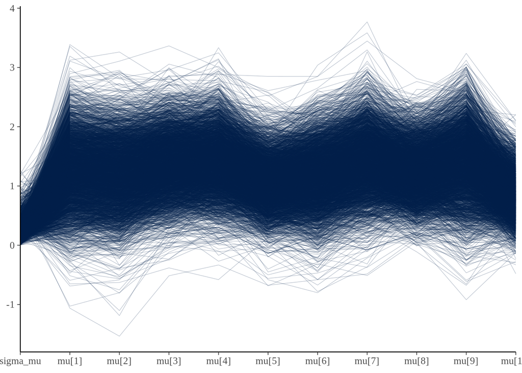

```r
parcoord_no_divs <- mcmc_parcoord(
  as.array(fitted_model_NB_hier_ncp, pars = c("sigma_mu", "mu")),
  np = nuts_params(fitted_model_NB_hier_ncp)
)
parcoord_no_divs
```

### Posterior predictive check

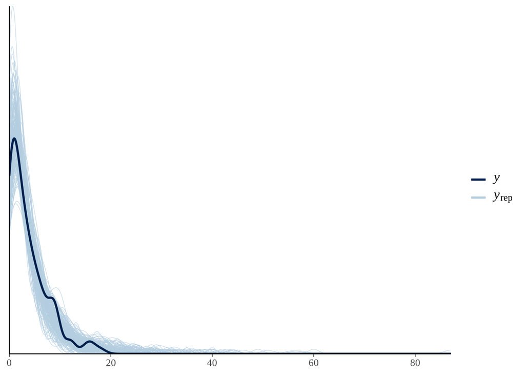

```r
samps_NB_hier_ncp <- rstan::extract(fitted_model_NB_hier_ncp, pars = c('y_rep','inv_phi'))
y_rep <- as.matrix(fitted_model_NB_hier_ncp, pars = "y_rep")
ppc_dens_overlay(stan_dat_hier$complaints, y_rep[1:200,])
```

```r
# qua ci sono 200 linee azzurre, una per ogni simulazione
# quella blu invece corrisponde ai dati

ppc_stat_grouped(
  y = stan_dat_hier$complaints,
  yrep = y_rep,
  group = pest_data$building_id,
  stat = 'mean',
  binwidth = 0.5
)
```

[figure not shown]

```r
ppc_stat_grouped(
  y = stan_dat_hier$complaints,
  yrep = y_rep,
  group = pest_data$building_id,
  stat = 'sd',
  binwidth = 0.5
)
```

[figure not shown]

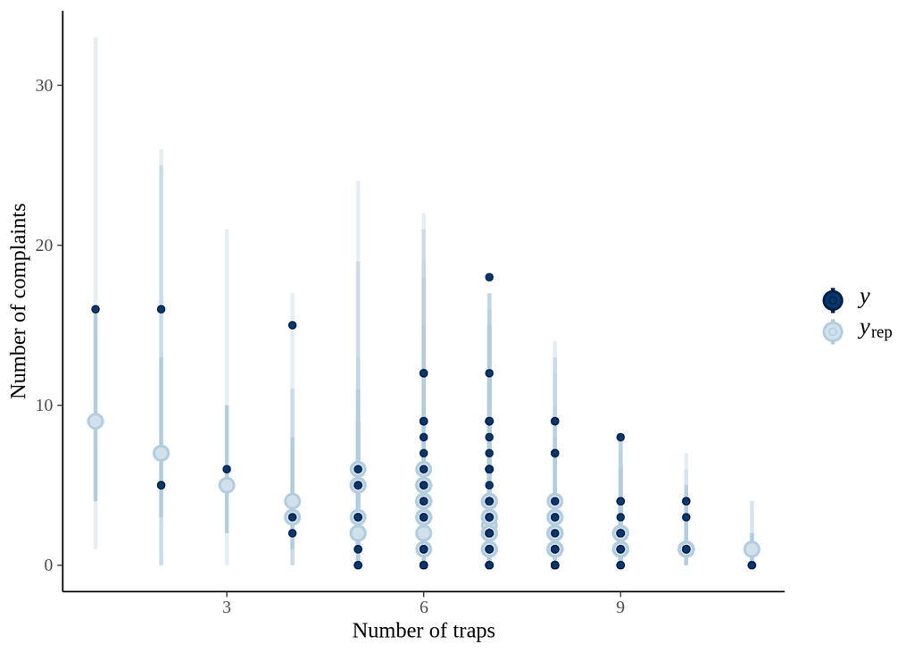

```r
ppc_intervals(
  y = stan_dat_hier$complaints,
  yrep = y_rep,
  x = stan_dat_hier$traps
) +
  labs(x = "Number of traps", y = "Number of complaints")
```

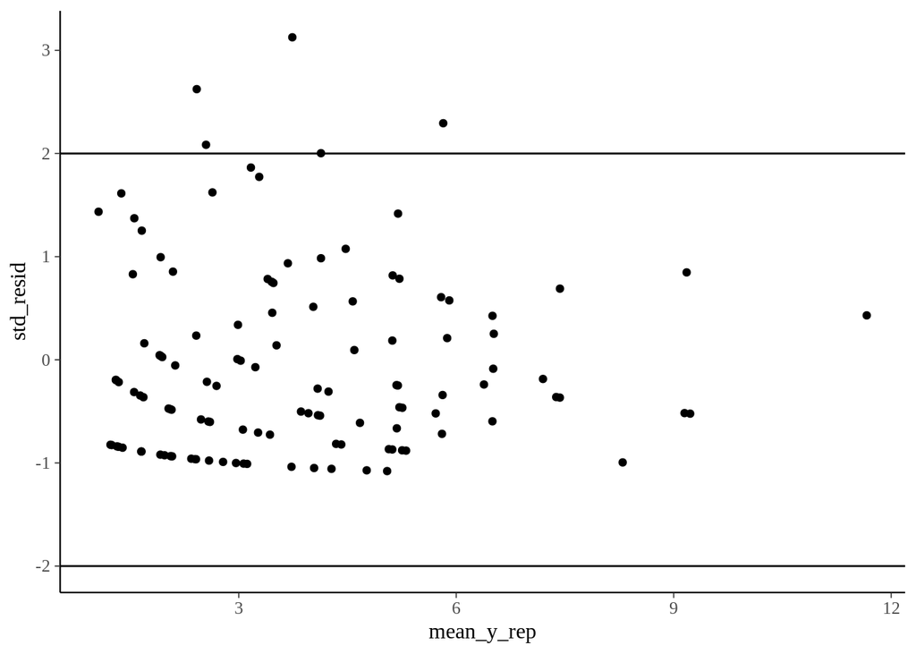

```r
mean_y_rep <- colMeans(y_rep)
mean_inv_phi <- mean(as.matrix(fitted_model_NB_hier_ncp, pars = "inv_phi"))
std_resid <- (stan_dat_hier$complaints - mean_y_rep) / sqrt(mean_y_rep + mean_y_rep^2*mean_inv_phi)
qplot(mean_y_rep, std_resid) + hline_at(2) + hline_at(-2)
```